# Tugas Besar IF2220 Probabilitas dan Statistika

## Penarikan Kesimpulan dan Pengujian Hipotesis

Karel Renaldi 13519180

Richard Rivaldo 13519185

Kelas 04 Teknik Informatika 2019

# Libraries

```python
import math
import scipy
import numpy as np
import pandas as pd
import seaborn as sns
import matplotlib.pyplot as plt
```

# Data Preprocessing

**Membaca dan Menambahkan *Header* pada Data**

```python
Gandum = pd.read_csv("Gandum.csv", names = ["id", "Daerah", "SumbuUtama", "SumbuKecil", "Keunikan", "AreaBulatan",
                  "Diameter", "KadarAir", "Keliling", "Bulatan", "Ransum", "Kelas"])
```

**Preview Data**

```python
Gandum.head(n = 10)
```

|  | id | Daerah | SumbuUtama | SumbuKecil | Keunikan | AreaBulatan | Diameter | KadarAir | Keliling | Bulatan | Ransum | Kelas |
| --- | --- | --- | --- | --- | --- | --- | --- | --- | --- | --- | --- | --- |
| 0 | 1 | 5781 | 128.288875 | 58.470846 | 0.890095 | 5954 | 85.793926 | 0.674090 | 316.756 | 0.724041 | 2.194066 | 1 |
| 1 | 2 | 4176 | 109.348294 | 49.837688 | 0.890098 | 4277 | 72.918093 | 0.596231 | 260.346 | 0.774227 | 2.194088 | 1 |
| 2 | 3 | 4555 | 114.427991 | 52.151207 | 0.890105 | 4706 | 76.155145 | 0.776641 | 279.606 | 0.732159 | 2.194158 | 1 |
| 3 | 4 | 4141 | 108.701191 | 49.457349 | 0.890499 | 4236 | 72.611879 | 0.633180 | 260.478 | 0.766960 | 2.197877 | 1 |
| 4 | 5 | 5273 | 122.747869 | 55.757848 | 0.890876 | 5431 | 81.937733 | 0.669842 | 302.730 | 0.723031 | 2.201446 | 1 |
| 5 | 6 | 5371 | 123.943530 | 56.235398 | 0.891145 | 5531 | 82.695644 | 0.734144 | 297.114 | 0.764573 | 2.204013 | 1 |
| 6 | 7 | 6332 | 135.249060 | 61.312148 | 0.891344 | 6528 | 89.789492 | 0.579747 | 328.799 | 0.736020 | 2.205910 | 1 |
| 7 | 8 | 5595 | 126.292008 | 57.238214 | 0.891398 | 5745 | 84.402460 | 0.621046 | 303.285 | 0.764378 | 2.206428 | 1 |
| 8 | 9 | 4664 | 115.859780 | 52.493440 | 0.891471 | 4826 | 77.060945 | 0.712170 | 282.980 | 0.731909 | 2.207129 | 1 |
| 9 | 10 | 5762 | 128.482339 | 58.165177 | 0.891658 | 5932 | 85.652824 | 0.659872 | 312.678 | 0.740608 | 2.208922 | 1 |

# Nomor 1: *Descriptive Statistics*

**Kolom *Daerah***

```python
print("Mean =", Gandum["Daerah"].mean())
print("Median =", Gandum["Daerah"].median())
modes = list(Gandum["Daerah"].mode())
print("Modus (%d data):" %len(modes))
if(len(modes) == 500):
  print("Semua data dalam kolom ini bersifat unik, menyebabkan modusnya berjumlah seperti ukuran kolom ini.")
else:
  for mode in modes:
    if mode != modes[-1]:
      print(mode, end = ", ")
    else:
      print(mode)
print("Standar Deviasi =", Gandum["Daerah"].std())
print("Variansi =", Gandum["Daerah"].var())
print("Range =", Gandum["Daerah"].max() - Gandum["Daerah"].min())
print("Min =", Gandum["Daerah"].min())
print("Max =", Gandum["Daerah"].max())
print("Kuartil 1 =", Gandum["Daerah"].quantile(0.25))
print("Kuartil 2 = Median =", Gandum["Daerah"].quantile(0.5))
print("Kuartil 3 =", Gandum["Daerah"].quantile(0.75))
print("Interquartile Range (IQR) =", Gandum["Daerah"].quantile(0.75) - Gandum["Daerah"].quantile(0.25))
print("Skewness =", Gandum["Daerah"].skew())
print("Kurtosis =", Gandum["Daerah"].kurtosis())
```

```
Mean = 4801.246
Median = 4735.0
Modus (4 data):
3992, 4881, 5642, 6083
Standar Deviasi = 986.3954914816018
Variansi = 972976.0656152307
Range = 4931
Min = 2522
Max = 7453
Kuartil 1 = 4042.75
Kuartil 2 = Median = 4735.0
Kuartil 3 = 5495.5
Interquartile Range (IQR) = 1452.75
Skewness = 0.23814408738280812
Kurtosis = -0.4346305340273977
```

**Kolom *SumbuUtama***

```python
print("Mean =", Gandum["SumbuUtama"].mean())
print("Median =", Gandum["SumbuUtama"].median())
modes = list(Gandum["SumbuUtama"].mode())
print("Modus (%d data):" %len(modes))
if(len(modes) == 500):
  print("Semua data dalam kolom ini bersifat unik, menyebabkan modusnya berjumlah seperti ukuran kolom ini.")
else:
  for mode in modes:
    if mode != modes[-1]:
      print(mode, end = ", ")
    else:
      print(mode)
print("Standar Deviasi =", Gandum["SumbuUtama"].std())
print("Variansi =", Gandum["SumbuUtama"].var())
print("Range =", Gandum["SumbuUtama"].max() - Gandum["SumbuUtama"].min())
print("Min =", Gandum["SumbuUtama"].min())
print("Max =", Gandum["SumbuUtama"].max())
print("Kuartil 1 =", Gandum["SumbuUtama"].quantile(0.25))
print("Kuartil 2 = Median =", Gandum["SumbuUtama"].quantile(0.5))
print("Kuartil 3 =", Gandum["SumbuUtama"].quantile(0.75))
print("Interquartile Range (IQR) =", Gandum["SumbuUtama"].quantile(0.75) - Gandum["SumbuUtama"].quantile(0.25))
print("Skewness =", Gandum["SumbuUtama"].skew())
print("Kurtosis =", Gandum["SumbuUtama"].kurtosis())
```

```
Mean = 116.04517136778003
Median = 115.40513994999999
Modus (500 data):
Semua data dalam kolom ini bersifat unik, menyebabkan modusnya berjumlah seperti ukuran kolom ini.
Standar Deviasi = 18.28262595755936
Variansi = 334.25441190402336
Range = 153.79546865999998
Min = 74.13311404
Max = 227.9285827
Kuartil 1 = 104.11609817499999
Kuartil 2 = Median = 115.40513994999999
Kuartil 3 = 129.046792025
Interquartile Range (IQR) = 24.93069385000001
Skewness = 0.7615287378076631
Kurtosis = 4.330533548436968
```

**Kolom *SumbuKecil***

```python
print("Mean =", Gandum["SumbuKecil"].mean())
print("Median =", Gandum["SumbuKecil"].median())
modes = list(Gandum["SumbuKecil"].mode())
print("Modus (%d data):" %len(modes))
if(len(modes) == 500):
  print("Semua data dalam kolom ini bersifat unik, menyebabkan modusnya berjumlah seperti ukuran kolom ini.")
else:
  for mode in modes:
    if mode != modes[-1]:
      print(mode, end = ", ")
    else:
      print(mode)
print("Standar Deviasi =", Gandum["SumbuKecil"].std())
print("Variansi =", Gandum["SumbuKecil"].var())
print("Range =", Gandum["SumbuKecil"].max() - Gandum["SumbuKecil"].min())
print("Min =", Gandum["SumbuKecil"].min())
print("Max =", Gandum["SumbuKecil"].max())
print("Kuartil 1 =", Gandum["SumbuKecil"].quantile(0.25))
print("Kuartil 2 = Median =", Gandum["SumbuKecil"].quantile(0.5))
print("Kuartil 3 =", Gandum["SumbuKecil"].quantile(0.75))
print("Interquartile Range (IQR) =", Gandum["SumbuKecil"].quantile(0.75) - Gandum["SumbuKecil"].quantile(0.25))
print("Skewness =", Gandum["SumbuKecil"].skew())
print("Kurtosis =", Gandum["SumbuKecil"].kurtosis())
```

```
Mean = 53.71524598896002
Median = 53.731198774999996
Modus (500 data):
Semua data dalam kolom ini bersifat unik, menyebabkan modusnya berjumlah seperti ukuran kolom ini.
Standar Deviasi = 4.071074752475035
Variansi = 16.573649640239662
Range = 29.071182429999993
Min = 39.90651744
Max = 68.97769987
Kuartil 1 = 51.1935763325
Kuartil 2 = Median = 53.731198774999996
Kuartil 3 = 56.3251579825
Interquartile Range (IQR) = 5.131581650000001
Skewness = -0.010828051555611359
Kurtosis = 0.47556845043813656
```

**Kolom *Keunikan***

```python
print("Mean =", Gandum["Keunikan"].mean())
print("Median =", Gandum["Keunikan"].median())
modes = list(Gandum["Keunikan"].mode())
print("Modus (%d data):" %len(modes))
if(len(modes) == 500):
  print("Semua data dalam kolom ini bersifat unik, menyebabkan modusnya berjumlah seperti ukuran kolom ini.")
else:
  for mode in modes:
    if mode != modes[-1]:
      print(mode, end = ", ")
    else:
      print(mode)
print("Standar Deviasi =", Gandum["Keunikan"].std())
print("Variansi =", Gandum["Keunikan"].var())
print("Range =", Gandum["Keunikan"].max() - Gandum["Keunikan"].min())
print("Min =", Gandum["Keunikan"].min())
print("Max =", Gandum["Keunikan"].max())
print("Kuartil 1 =", Gandum["Keunikan"].quantile(0.25))
print("Kuartil 2 = Median =", Gandum["Keunikan"].quantile(0.5))
print("Kuartil 3 =", Gandum["Keunikan"].quantile(0.75))
print("Interquartile Range (IQR) =", Gandum["Keunikan"].quantile(0.75) - Gandum["Keunikan"].quantile(0.25))
print("Skewness =", Gandum["Keunikan"].skew())
print("Kurtosis =", Gandum["Keunikan"].kurtosis())
```

```
Mean = 0.878763914340001
Median = 0.8900454185
Modus (500 data):
Semua data dalam kolom ini bersifat unik, menyebabkan modusnya berjumlah seperti ukuran kolom ini.
Standar Deviasi = 0.03658590550477702
Variansi = 0.0013385284816044736
Range = 0.19408517999999997
Min = 0.7199162259999999
Max = 0.9140014059999999
Kuartil 1 = 0.8636757527500001
Kuartil 2 = Median = 0.8900454185
Kuartil 3 = 0.907577917
Interquartile Range (IQR) = 0.04390216424999993
Skewness = -1.6234718222806501
Kurtosis = 2.917255925694389
```

**Kolom *AreaBulatan***

```python
print("Mean =", Gandum["AreaBulatan"].mean())
print("Median =", Gandum["AreaBulatan"].median())
modes = list(Gandum["AreaBulatan"].mode())
print("Modus (%d data):" %len(modes))
if(len(modes) == 500):
  print("Semua data dalam kolom ini bersifat unik, menyebabkan modusnya berjumlah seperti ukuran kolom ini.")
else:
  for mode in modes:
    if mode != modes[-1]:
      print(mode, end = ", ")
    else:
      print(mode)
print("Standar Deviasi =", Gandum["AreaBulatan"].std())
print("Variansi =", Gandum["AreaBulatan"].var())
print("Range =", Gandum["AreaBulatan"].max() - Gandum["AreaBulatan"].min())
print("Min =", Gandum["AreaBulatan"].min())
print("Max =", Gandum["AreaBulatan"].max())
print("Kuartil 1 =", Gandum["AreaBulatan"].quantile(0.25))
print("Kuartil 2 = Median =", Gandum["AreaBulatan"].quantile(0.5))
print("Kuartil 3 =", Gandum["AreaBulatan"].quantile(0.75))
print("Interquartile Range (IQR) =", Gandum["AreaBulatan"].quantile(0.75) - Gandum["AreaBulatan"].quantile(0.25))
print("Skewness =", Gandum["AreaBulatan"].skew())
print("Kurtosis =", Gandum["AreaBulatan"].kurtosis())
```

```
Mean = 4937.048
Median = 4857.0
Modus (2 data):
3802, 4913
Standar Deviasi = 1011.6962549701573
Variansi = 1023529.3123206415
Range = 5141
Min = 2579
Max = 7720
Kuartil 1 = 4170.25
Kuartil 2 = Median = 4857.0
Kuartil 3 = 5654.25
Interquartile Range (IQR) = 1484.0
Skewness = 0.2575600053152032
Kurtosis = -0.40968492037366033
```

**Kolom *Diameter***

```python
print("Mean =", Gandum["Diameter"].mean())
print("Median =", Gandum["Diameter"].median())
modes = list(Gandum["Diameter"].mode())
print("Modus (%d data):" %len(modes))
if(len(modes) == 500):
  print("Semua data dalam kolom ini bersifat unik, menyebabkan modusnya berjumlah seperti ukuran kolom ini.")
else:
  for mode in modes:
    if mode != modes[-1]:
      print(mode, end = ", ")
    else:
      print(mode)
print("Standar Deviasi =", Gandum["Diameter"].std())
print("Variansi =", Gandum["Diameter"].var())
print("Range =", Gandum["Diameter"].max() - Gandum["Diameter"].min())
print("Min =", Gandum["Diameter"].min())
print("Max =", Gandum["Diameter"].max())
print("Kuartil 1 =", Gandum["Diameter"].quantile(0.25))
print("Kuartil 2 = Median =", Gandum["Diameter"].quantile(0.5))
print("Kuartil 3 =", Gandum["Diameter"].quantile(0.75))
print("Interquartile Range (IQR) =", Gandum["Diameter"].quantile(0.75) - Gandum["Diameter"].quantile(0.25))
print("Skewness =", Gandum["Diameter"].skew())
print("Kurtosis =", Gandum["Diameter"].kurtosis())
```

```
Mean = 77.77115780832005
Median = 77.64527658
Modus (4 data):
71.29356396, 78.83325579, 84.75622403, 88.00634154
Standar Deviasi = 8.056867291849715
Variansi = 64.91311055847777
Range = 40.747172240000005
Min = 56.66665803
Max = 97.41383027
Kuartil 1 = 71.74530754749999
Kuartil 2 = Median = 77.64527658
Kuartil 3 = 83.6485975675
Interquartile Range (IQR) = 11.903290020000014
Skewness = 0.002724966865193717
Kurtosis = -0.4664545130312141
```

**Kolom *KadarAir***

```python
print("Mean =", Gandum["KadarAir"].mean())
print("Median =", Gandum["KadarAir"].median())
modes = list(Gandum["KadarAir"].mode())
print("Modus (%d data):" %len(modes))
if(len(modes) == 500):
  print("Semua data dalam kolom ini bersifat unik, menyebabkan modusnya berjumlah seperti ukuran kolom ini.")
else:
  for mode in modes:
    if mode != modes[-1]:
      print(mode, end = ", ")
    else:
      print(mode)
print("Standar Deviasi =", Gandum["KadarAir"].std())
print("Variansi =", Gandum["KadarAir"].var())
print("Range =", Gandum["KadarAir"].max() - Gandum["KadarAir"].min())
print("Min =", Gandum["KadarAir"].min())
print("Max =", Gandum["KadarAir"].max())
print("Kuartil 1 =", Gandum["KadarAir"].quantile(0.25))
print("Kuartil 2 = Median =", Gandum["KadarAir"].quantile(0.5))
print("Kuartil 3 =", Gandum["KadarAir"].quantile(0.75))
print("Interquartile Range (IQR) =", Gandum["KadarAir"].quantile(0.75) - Gandum["KadarAir"].quantile(0.25))
print("Skewness =", Gandum["KadarAir"].skew())
print("Kurtosis =", Gandum["KadarAir"].kurtosis())
```

```
Mean = 0.6483716718980002
Median = 0.626116699
Modus (2 data):
0.735849057, 0.824404762
Standar Deviasi = 0.0943670980937953
Variansi = 0.008905149202643984
Range = 0.46897193099999995
Min = 0.409927152
Max = 0.878899083
Kuartil 1 = 0.57263245725
Kuartil 2 = Median = 0.626116699
Kuartil 3 = 0.7266333445000001
Interquartile Range (IQR) = 0.15400088725000005
Skewness = 0.49366131797330265
Kurtosis = -0.7403261705867821
```

**Kolom *Keliling***

```python
print("Mean =", Gandum["Keliling"].mean())
print("Median =", Gandum["Keliling"].median())
modes = list(Gandum["Keliling"].mode())
print("Modus (%d data):" %len(modes))
if(len(modes) == 500):
  print("Semua data dalam kolom ini bersifat unik, menyebabkan modusnya berjumlah seperti ukuran kolom ini.")
else:
  for mode in modes:
    if mode != modes[-1]:
      print(mode, end = ", ")
    else:
      print(mode)
print("Standar Deviasi =", Gandum["Keliling"].std())
print("Variansi =", Gandum["Keliling"].var())
print("Range =", Gandum["Keliling"].max() - Gandum["Keliling"].min())
print("Min =", Gandum["Keliling"].min())
print("Max =", Gandum["Keliling"].max())
print("Kuartil 1 =", Gandum["Keliling"].quantile(0.25))
print("Kuartil 2 = Median =", Gandum["Keliling"].quantile(0.5))
print("Kuartil 3 =", Gandum["Keliling"].quantile(0.75))
print("Interquartile Range (IQR) =", Gandum["Keliling"].quantile(0.75) - Gandum["Keliling"].quantile(0.25))
print("Skewness =", Gandum["Keliling"].skew())
print("Kurtosis =", Gandum["Keliling"].kurtosis())
```

```
Mean = 281.479722
Median = 280.04549999999995
Modus (500 data):
Semua data dalam kolom ini bersifat unik, menyebabkan modusnya berjumlah seperti ukuran kolom ini.
Standar Deviasi = 37.335401715143995
Variansi = 1393.9322212311772
Range = 291.822
Min = 197.015
Max = 488.837
Kuartil 1 = 255.88299999999998
Kuartil 2 = Median = 280.04549999999995
Kuartil 3 = 306.0625
Interquartile Range (IQR) = 50.17950000000002
Skewness = 0.7336269072005543
Kurtosis = 2.272684731245571
```

**Kolom *Bulatan***

```python
print("Mean =", Gandum["Bulatan"].mean())
print("Median =", Gandum["Bulatan"].median())
modes = list(Gandum["Bulatan"].mode())
print("Modus (%d data):" %len(modes))
if(len(modes) == 500):
  print("Semua data dalam kolom ini bersifat unik, menyebabkan modusnya berjumlah seperti ukuran kolom ini.")
else:
  for mode in modes:
    if mode != modes[-1]:
      print(mode, end = ", ")
    else:
      print(mode)
print("Standar Deviasi =", Gandum["Bulatan"].std())
print("Variansi =", Gandum["Bulatan"].var())
print("Range =", Gandum["Bulatan"].max() - Gandum["Bulatan"].min())
print("Min =", Gandum["Bulatan"].min())
print("Max =", Gandum["Bulatan"].max())
print("Kuartil 1 =", Gandum["Bulatan"].quantile(0.25))
print("Kuartil 2 = Median =", Gandum["Bulatan"].quantile(0.5))
print("Kuartil 3 =", Gandum["Bulatan"].quantile(0.75))
print("Interquartile Range (IQR) =", Gandum["Bulatan"].quantile(0.75) - Gandum["Bulatan"].quantile(0.25))
print("Skewness =", Gandum["Bulatan"].skew())
print("Kurtosis =", Gandum["Bulatan"].kurtosis())
```

```
Mean = 0.7617374363080005
Median = 0.7612884395
Modus (500 data):
Semua data dalam kolom ini bersifat unik, menyebabkan modusnya berjumlah seperti ukuran kolom ini.
Standar Deviasi = 0.0617024607867326
Variansi = 0.0038071936671382743
Range = 0.7301581349999999
Min = 0.174590178
Max = 0.9047483129999999
Kuartil 1 = 0.731990728
Kuartil 2 = Median = 0.7612884395
Kuartil 3 = 0.79636096975
Interquartile Range (IQR) = 0.06437024175000006
Skewness = -3.5992367663616407
Kurtosis = 29.97509590463005
```

**Kolom *Ransum***

```python
print("Mean =", Gandum["Ransum"].mean())
print("Median =", Gandum["Ransum"].median())
modes = list(Gandum["Ransum"].mode())
print("Modus (%d data):" %len(modes))
if(len(modes) == 500):
  print("Semua data dalam kolom ini bersifat unik, menyebabkan modusnya berjumlah seperti ukuran kolom ini.")
else:
  for mode in modes:
    if mode != modes[-1]:
      print(mode, end = ", ")
    else:
      print(mode)
print("Standar Deviasi =", Gandum["Ransum"].std())
print("Variansi =", Gandum["Ransum"].var())
print("Range =", Gandum["Ransum"].max() - Gandum["Ransum"].min())
print("Min =", Gandum["Ransum"].min())
print("Max =", Gandum["Ransum"].max())
print("Kuartil 1 =", Gandum["Ransum"].quantile(0.25))
print("Kuartil 2 = Median =", Gandum["Ransum"].quantile(0.5))
print("Kuartil 3 =", Gandum["Ransum"].quantile(0.75))
print("Interquartile Range (IQR) =", Gandum["Ransum"].quantile(0.75) - Gandum["Ransum"].quantile(0.25))
print("Skewness =", Gandum["Ransum"].skew())
print("Kurtosis =", Gandum["Ransum"].kurtosis())
```

```
Mean = 2.150915331084002
Median = 2.1935990365
Modus (500 data):
Semua data dalam kolom ini bersifat unik, menyebabkan modusnya berjumlah seperti ukuran kolom ini.
Standar Deviasi = 0.24976688927065827
Variansi = 0.06238349897594127
Range = 1.0240129659999997
Min = 1.440795615
Max = 2.4648085809999998
Kuartil 1 = 1.98393879075
Kuartil 2 = Median = 2.1935990365
Kuartil 3 = 2.38161221825
Interquartile Range (IQR) = 0.3976734275
Skewness = -0.6581880925333653
Kurtosis = -0.4286557930626156
```

# Nomor 2: Visualisasi Distribusi Data

**Kolom *Daerah***

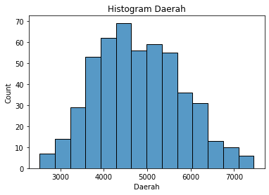

```python
sns.histplot(data = Gandum, x = 'Daerah')
plt.title("Histogram Daerah")
plt.show()
```

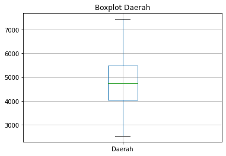

```python
Gandum.boxplot(column=['Daerah'])
plt.title("Boxplot Daerah")
plt.show()
```

**Kolom *SumbuUtama***

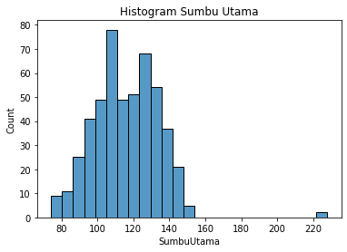

```python
sns.histplot(data = Gandum, x = "SumbuUtama")
plt.title("Histogram Sumbu Utama")
plt.show()
```

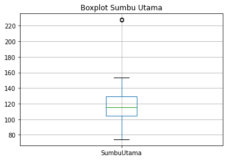

```python
Gandum.boxplot(column=['SumbuUtama'])
plt.title("Boxplot Sumbu Utama")
plt.show()
```

**Kolom *SumbuKecil***

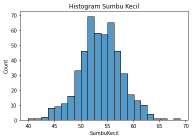

```python
sns.histplot(data = Gandum, x = "SumbuKecil")
plt.title("Histogram Sumbu Kecil")
plt.show()
```

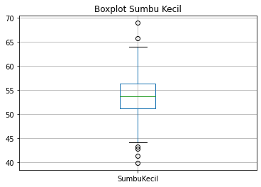

```python
Gandum.boxplot(column=['SumbuKecil'])
plt.title("Boxplot Sumbu Kecil")
plt.show()
```

*Dari Histogram di atas dapat terlihat bahwa secara kasar kolom `SumbuKecil` dapat dikatakan memiliki data yang juga sedikit multimodal, namun kurang multimodal jika dibandingkan data sebelumnya, karena terdapat dua buah nilai yang cukup tinggi sebagai puncak histogram tetapi nilai ini tidak terlalu berbeda dengan nilai di bawahnya. Pada data ini, nilai median memiliki frekuensi yang tidak terlalu banyak sehingga frekuensi maksimum data bukan berasal dari nilai tengahnya. Selain itu, data memiliki tendensi untuk bernilai dekat dengan nilai median, dan data-data dengan nilai yang semakin jauh dari median memiliki jumlah yang semakin mengecil. Secara kasar dapat terlihat bahwa data ini cukup simetris, sehingga bisa dikatakan bahwa data ini berdistribusi normal. Dari Boxplot yang ada, maka dapat diketahui bahwa data merentang pada kisaran 43 untuk nilai minimum sampai dengan nilai maksimum di kisaran 64 dengan median pada angka 53-an. Hal ini sesuai dengan analisis deskriptif yang dilakukan sebelumnya. Untuk Boxplot ini juga, panjang whiskers dari Boxplot dan nilai median pada Box terlihat cukup simetris. Hal ini sesuai dengan kesimpulan distribusi normal yang didapat dari Histogram tadi. Namun, data ini dapat dikatakan sebagai data yang kurang baik karena pada data ini terdapat banyak data pencilan atas maupun data pencilan bawah meskipun dalam jumlah kecil yang lebih terlihat jelas pada Boxplot di atas.*

**Kolom *Keunikan***

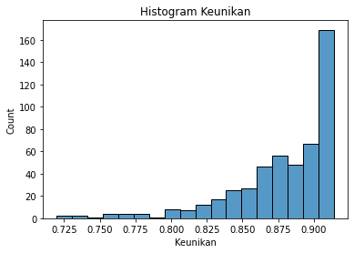

```python
sns.histplot(data = Gandum, x = "Keunikan")
plt.title("Histogram Keunikan")
plt.show()
```

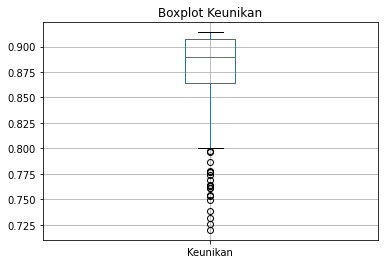

```python
Gandum.boxplot(column=['Keunikan'])
plt.title("Boxplot Keunikan")
plt.show()
```

*Dari Histogram di atas dapat terlihat jelas bahwa kolom `Keunikan` dapat memiliki distribusi yang negatively skewed. Pada data ini, nilai median memiliki frekuensi yang tidak terlalu banyak, dan nilai dengan frekuensi tertinggi merupakan nilai pinggiran atas atau nilai maksimumnya. Data memiliki tendensi untuk memiliki frekuensi yang semakin sedikit, jika nilainya semakin jauh dibandingkan nilai maksimum tadi. Pada Histogram, juga terlihat bahwa data memiliki banyak pencilan bawah dan hal ini juga terkonfirmasi melalui Boxplot yang ada. Selain itu, dapat dikatakan bahwa data merentang pada kisaran 0.8 untuk nilai minimum sampai dengan nilai maksimum di kisaran 0.90 dengan median pada angka 0.88-an. Hal ini sesuai dengan analisis deskriptif yang dilakukan sebelumnya. Untuk Boxplot ini juga, panjang whiskers dari Boxplot lebih panjang di bawah dan nilai median pada Box lebih bergerak ke atas. Dengan demikian, hal ini mengonfirmasi bahwa data memang lebih condong ke kiri dan bersifat left-skewed. Namun, data ini dapat dikatakan sebagai data yang kurang baik karena pada data ini terdapat banyak sekali data pencilan bawah yang lebih terlihat jelas pada Boxplot di atas.*

**Kolom *AreaBulatan***

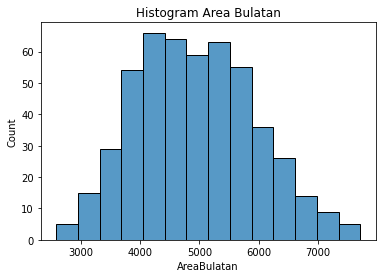

```python
sns.histplot(data = Gandum, x = "AreaBulatan")
plt.title("Histogram Area Bulatan")
plt.show()
```

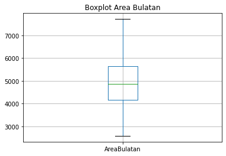

```python
Gandum.boxplot(column=['AreaBulatan'])
plt.title("Boxplot Area Bulatan")
plt.show()
```

**Kolom *Diameter***

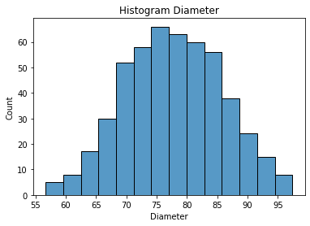

```python
sns.histplot(data = Gandum, x = "Diameter")
plt.title("Histogram Diameter")
plt.show()
```

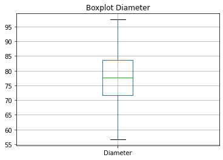

```python
Gandum.boxplot(column=['Diameter'])
plt.title("Boxplot Diameter")
plt.show()
```

*Dari Histogram di atas dapat terlihat bahwa kolom `Diameter` memiliki distribusi data yang cukup simetris sehingga data ini memiliki probabilitas yang cukup tinggi untuk menjadi data yang berdistribusi normal. Pada data ini, nilai median memiliki frekuensi yang paling tinggi. Data memiliki tendensi untuk memiliki frekuensi yang semakin sedikit, jika nilainya semakin jauh dari nilai tengah data. Dari Boxplot yang ada, dapat dikatakan bahwa data merentang pada kisaran 57 untuk nilai minimum sampai dengan nilai maksimum di kisaran 97 dengan median pada angka 77-an. Hal ini sesuai dengan analisis deskriptif yang dilakukan sebelumnya. Untuk Boxplot ini juga, panjang whiskers dari Boxplot dan nilai median pada Box cukup simetris. Dengan demikian, hal ini memperkuat dugaan bahwa data `Diameter` memiliki distribusi normal. Pada Boxplot juga dapat terlihat bahwa data ini tidak memiliki data pencilan sama sekali.*

**Kolom *KadarAir***

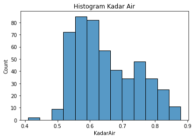

```python
sns.histplot(data = Gandum, x = "KadarAir")
plt.title("Histogram Kadar Air")
plt.show()
```

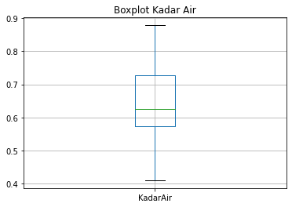

```python
Gandum.boxplot(column=['KadarAir'])
plt.title("Boxplot Kadar Air")
plt.show()
```

*Dari Histogram di atas dapat terlihat jelas bahwa kolom `KadarAir` memiliki data yang sedikit right-skewed. karena data-data bernilai kecil memiliki frekuensi yang lebih tinggi dibandingkan data-data pada kuartil atas. Pada data ini, nilai median memiliki frekuensi yang tidak terlalu banyak, dan nilai dengan frekuensi tertinggi merupakan nilai pinggiran bawahnya. Data memiliki tendensi untuk memiliki frekuensi yang semakin sedikit, jika nilainya semakin besar, namun ada beberapa data bernilai kecil yang juga memiliki frekuensi yang sedikit, sehingga data ini dapat dikatakan tidak terlalu condong kanan. Pada Histogram, terlihat sekilas bahwa ada data pencilan bawah yang jumlahnya kecil, namun pada Boxplot tidak ada data pencilan sama sekali. Hal ini memang relevan karena Boxplot lebih menggambarkan distribusi data pencilan dibandingkan Histogram. Selain itu, dapat dikatakan bahwa data merentang pada kisaran 0.4 untuk nilai minimum sampai dengan nilai maksimum di kisaran 0.88 dengan median pada angka 0.62-an. Hal ini sesuai dengan analisis deskriptif yang dilakukan sebelumnya. Untuk Boxplot ini juga, panjang whiskers dari Boxplot cukup simetris tetapi nilai median pada Box lebih bergerak ke bawah. Dengan demikian, kecondongan data tidak terlalu bisa digambarkan melalui kedua visualisasi ini.*

**Kolom *Keliling***

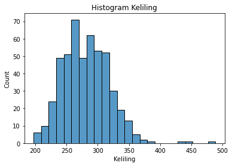

```python
sns.histplot(data = Gandum, x = "Keliling")
plt.title("Histogram Keliling")
plt.show()
```

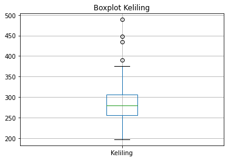

```python
Gandum.boxplot(column=['Keliling'])
plt.title("Boxplot Keliling")
plt.show()
```

*Dari Histogram di atas dapat terlihat bahwa kolom `Keliling` belum bisa dikatakan sebagai data yang berdistribusi normal, namun sedikit multimodal dengan dua puncak Histogram yang bukan median. Pada data ini, nilai median memiliki frekuensi yang tidak terlalu banyak. Data memiliki tendensi untuk memiliki nilai yang dekat dengan nilai median. Pada Histogram, juga terlihat bahwa data memiliki banyak pencilan atas dan hal ini juga terkonfirmasi melalui Boxplot yang ada. Selain itu, dapat dikatakan bahwa data merentang pada kisaran 200 untuk nilai minimum sampai dengan nilai maksimum di kisaran 375 dengan median pada angka 275-an. Hal ini sesuai dengan analisis deskriptif yang dilakukan sebelumnya. Untuk Boxplot ini juga, panjang whiskers dari Boxplot dan nilai median pada Box cukup simetris. Dengan demikian, distribusi data tidak bisa ditentukan tanpa tes kuantitatif lebih lanjut.*

**Kolom *Bulatan***

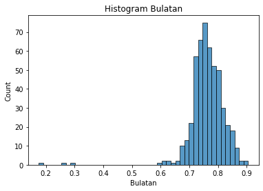

```python
sns.histplot(data = Gandum, x = "Bulatan")
plt.title("Histogram Bulatan")
plt.show()
```

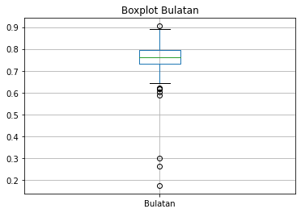

```python
Gandum.boxplot(column=['Bulatan'])
plt.title("Boxplot Bulatan")
plt.show()
```

*Dari Histogram di atas dapat terlihat secara kasar bahwa kolom `Bulatan` memiliki distribusi yang lebih negatively skewed. Pada data ini, nilai median memiliki frekuensi yang tidak terlalu banyak, dan nilai dengan frekuensi tertinggi merupakan nilai yang lebih kecil dibandingkan dengan mediannya. Data memiliki tendensi untuk memiliki frekuensi yang semakin sedikit jika nilainya lebih kecil dibandingkan dengan nilai median. Pada Histogram, juga terlihat bahwa data memiliki banyak data pencilan bawah dan sedikit data pencilan atas. Hal ini juga terkonfirmasi melalui Boxplot yang ada. Selain itu, dapat dikatakan bahwa data merentang pada kisaran 0.65 untuk nilai minimum sampai dengan nilai maksimum di kisaran 0.90 dengan median pada angka 0.75-an. Hal ini sesuai dengan analisis deskriptif yang dilakukan sebelumnya. Untuk Boxplot ini juga, panjang whiskers dari Boxplot dan nilai median pada Box cukup simetris. Dengan demikian, hal ini tidak bisa mengonfirmasi kecondongan data yang terlihat pada histogram.*

**Kolom *Ransum***

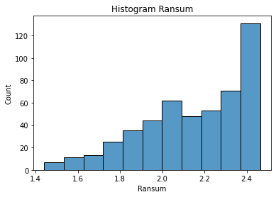

```python
sns.histplot(data = Gandum, x = "Ransum")
plt.title("Histogram Ransum")
plt.show()
```

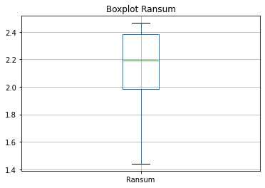

```python
Gandum.boxplot(column=['Ransum'])
plt.title("Boxplot Ransum")
plt.show()
```

*Dari Histogram di atas dapat terlihat jelas bahwa kolom `Ransum` dapat memiliki distribusi yang negatively skewed. Pada data ini, nilai median memiliki frekuensi yang tidak terlalu banyak, dan nilai dengan frekuensi tertinggi merupakan nilai pinggiran atas atau nilai maksimumnya. Data memiliki tendensi untuk memiliki frekuensi yang semakin sedikit, jika nilainya semakin jauh dibandingkan nilai maksimum tadi. Dari Boxplot dapat dikatakan bahwa data merentang pada kisaran 1.4 untuk nilai minimum sampai dengan nilai maksimum di kisaran 2.47 dengan median pada angka 2.2-an. Hal ini sesuai dengan analisis deskriptif yang dilakukan sebelumnya. Untuk Boxplot ini juga, panjang whiskers dari Boxplot lebih panjang di bawah dan nilai median pada Box lebih bergerak ke atas. Dengan demikian, hal ini mengonfirmasi bahwa data memang lebih condong ke kiri dan bersifat left-skewed. Melalui Boxplot dan Histogram di atas juga dapat dikatakan bahwa data ini tidak memiliki data pencilan sama sekali.*

# Nomor 3: *Normality Test*

*Pada Normality Test ini digunakan metode testing yang dicetuskan `Shapiro-Wilk` dengan menggunakan bantuan pustaka `Scipy`. Dalam implementasinya akan digunakan tingkat signifikansi (`Alpha`) yang bernilai `0.05` sebagai nilai yang umum digunakan. Nilai Alpha ini akan menjadi sebuah threshold pengecekan Normality Test Shapiro-Wilk.*

*Dengan menggunakan pustaka Scipy, maka Shapiro-Wilk akan menghasilkan dua buah nilai. Nilai pertama merupakan nilai `W statistics` yang merupakan hasil perhitungan dengan simulasi Monte Carlo untuk mengecek apabila suatu sampel acak berasal dari data yang terdistribusi normal. Nilai W Statistics yang kecil menandakan bahwa data yang dihitung tidaklah berdistribusi normal. Nilai kedua menyatakan nilai probabilitas `p-value`, yang jika lebih kecil dari tingkat signifikansi tertentu akan mengimplikasikan bahwa data tersebut tidak berdistribusi normal.*

*Normality Test dengan metode Shapiro-Wilk sering disebut sebagai salah satu metode terbaik dalam hal pengecekan distribusi data. Hal ini dikarenakan metode Shapiro-Wilk dihitung berdasarkan korelasi data-data yang ada serta skor normal yang berkaitan dengan data tersebut. Dengan demikian, metode ini akan memiliki kemampuan pendeteksian suatu data berdistribusi normal atau tidak, dan dalam hal ini lebih baik dibandingkan dengan metode tes Kolmogorov-Smirnow meskipun setelah dipengaruhi oleh koreksi Lilliefors.*

```python
def shapiro_normality_test(data):
  alpha = 0.05
  w_statistics, p_value = scipy.stats.shapiro(data)

  if(p_value > alpha):
    print("Data", data.name, "pada dataset Gandum berdistribusi normal dengan p-value yang melebihi tingkat signifikansi 0.05, yaitu %.6f.\n" %p_value)
  else:
    print("Data", data.name, "pada dataset Gandum tidak berdistribusi normal karena p-value tidak melebihi tingkat signifikansi 0.05, yaitu %.6f.\n" %p_value)
```

```python
print("Normality Test dengan Metode Shapiro-Wilk dan Tingkat Signifikansi (Alpha) 0.05:")
for column_name in Gandum.columns[1:len(Gandum.columns) - 1]:
  shapiro_normality_test(Gandum[column_name])
```

```
Normality Test dengan Metode Shapiro-Wilk dan Tingkat Signifikansi (Alpha) 0.05:
Data Daerah pada dataset Gandum tidak berdistribusi normal karena p-value tidak melebihi tingkat signifikansi 0.05, yaitu 0.003271.

Data SumbuUtama pada dataset Gandum tidak berdistribusi normal karena p-value tidak melebihi tingkat signifikansi 0.05, yaitu 0.000000.

Data SumbuKecil pada dataset Gandum berdistribusi normal dengan p-value yang melebihi tingkat signifikansi 0.05, yaitu 0.423456.

Data Keunikan pada dataset Gandum tidak berdistribusi normal karena p-value tidak melebihi tingkat signifikansi 0.05, yaitu 0.000000.

Data AreaBulatan pada dataset Gandum tidak berdistribusi normal karena p-value tidak melebihi tingkat signifikansi 0.05, yaitu 0.002485.

Data Diameter pada dataset Gandum berdistribusi normal dengan p-value yang melebihi tingkat signifikansi 0.05, yaitu 0.118345.

Data KadarAir pada dataset Gandum tidak berdistribusi normal karena p-value tidak melebihi tingkat signifikansi 0.05, yaitu 0.000000.

Data Keliling pada dataset Gandum tidak berdistribusi normal karena p-value tidak melebihi tingkat signifikansi 0.05, yaitu 0.000000.

Data Bulatan pada dataset Gandum tidak berdistribusi normal karena p-value tidak melebihi tingkat signifikansi 0.05, yaitu 0.000000.

Data Ransum pada dataset Gandum tidak berdistribusi normal karena p-value tidak melebihi tingkat signifikansi 0.05, yaitu 0.000000.
```

**Kolom *Daerah***

*Kolom `Daerah` merupakan data yang tidak berdistribusi normal karena p-value dari data ini tidak melebihi tingkat signifikansi yang ada. Hal ini bisa terlihat dari bentuk dan karakteristik data yang divisualisasikan dengan histogram di atas, di mana visualisasi pada histogram terlihat tidak simetris secara keseluruhan. Selain itu, nilai mediannya tidak memiliki frekuensi tertinggi sehingga dapat dikatakan bahwa data pada kolom ini tidak berdistribusi normal dan hal ini diperkuat dengan fakta perhitungan normality test nya.*

**Kolom *SumbuUtama***

*Kolom `SumbuUtama` merupakan data yang tidak berdistribusi normal karena p-value dari data ini tidak melebihi tingkat signifikansi yang ada. Hal ini bisa terlihat dari bentuk dan karakteristik data yang divisualisasikan dengan histogram di atas, di mana kolom `SumbuUtama` dapat dikatakan memiliki data yang sedikit multimodal karena terdapat dua buah nilai yang cukup tinggi sebagai puncak histogram. Pada data ini, nilai median memiliki frekuensi yang tidak terlalu banyak sehingga frekuensi maksimum data bukan berasal dari nilai tengahnya. Fakta bahwa kolom ini tidak berdistribusi normal juga diperkuat dan dibuktikan dengan hasil normality test di atas.*

**Kolom *SumbuKecil***

*Kolom `SumbuKecil` merupakan data yang berdistribusi normal karena p-value dari data ini melebihi tingkat signifikansi yang ada. Hal ini bisa terlihat dari bentuk dan karakteristik data yang divisualisasikan dengan histogram di atas, di mana dapat terlihat bahwa kolom `SumbuKecil` dapat dikatakan memiliki data yang juga sedikit multimodal, namun kurang multimodal jika dibandingkan data sebelum pada `SumbuUtama`, karena terdapat dua buah nilai yang cukup tinggi sebagai puncak histogram tetapi nilai ini tidak terlalu berbeda dengan nilai di bawahnya. Meskipun demikian, secara grafis data ini dapat dilihat memiliki visualisasi yang cukup simetris sehingga data ini juga masih dapat dibilang sebagai data berdistribusi normal. Hal ini juga dibuktikan dengan perhitungan normality test di atas.*

**Kolom *Keunikan***

*Kolom `Keunikan` merupakan data yang tidak berdistribusi normal karena p-value dari data ini tidak melebihi tingkat signifikansi yang ada. Hal ini bisa terlihat dari bentuk dan karakteristik data yang divisualisasikan dengan histogram di atas, di mana kolom `Keunikan` dapat memiliki distribusi yang negatively skewed. Pada data ini, nilai median juga memiliki frekuensi yang tidak terlalu banyak, dan nilai dengan frekuensi tertinggi merupakan nilai pinggiran atas atau nilai maksimumnya. Data pada kolom ini juga memiliki tendensi untuk memiliki frekuensi yang semakin sedikit, jika nilainya semakin jauh dibandingkan nilai maksimum tadi. Dengan demikian, kolom `Keunikan` ini tidak berdistribusi normal dan hal ini diperkuat dengan normality test di atas.*

**Kolom *AreaBulatan***

*Kolom `AreaBulatan` merupakan data yang tidak berdistribusi normal karena p-value dari data ini tidak melebihi tingkat signifikansi yang ada. Hal ini bisa terlihat dari bentuk dan karakteristik data yang divisualisasikan dengan histogram di atas, di mana hasil visualisasi dari kolom ini mirip seperti hasil visualisasi pada kolom `Area` sehingga kolom ini juga belum bisa dikatakan berdistribusi normal. Hal ini juga diperkuat dan dibuktikan dengan normality test yang dilakukan di atas.*

**Kolom *Diameter***

*Kolom `Diameter` merupakan data yang berdistribusi normal karena p-value dari data ini melebihi tingkat signifikansi yang ada. Hal ini bisa terlihat dari bentuk dan karakteristik data yang divisualisasikan dengan histogram di atas, di mana dapat terlihat bahwa kolom `Diameter` ini memiliki distribusi data yang cukup simetris sehingga data ini memiliki probabilitas yang cukup tinggi untuk menjadi data yang berdistribusi normal. Selain itu, fakta ini juga dibuktikan dengan hasil dari normality test di atas.*

**Kolom *KadarAir***

*Kolom `KadarAir` merupakan data yang tidak berdistribusi normal karena p-value dari data ini tidak melebihi tingkat signifikansi yang ada. Hal ini bisa terlihat dari bentuk dan karakteristik data yang divisualisasikan dengan histogram di atas, di mana terlihat bahwa kolom `KadarAir` memiliki data yang sedikit right-skewed karena data-data bernilai kecil memiliki frekuensi yang lebih tinggi dibandingkan data-data pada kuartil atas. Pada data ini, nilai median memiliki frekuensi yang tidak terlalu banyak, dan nilai dengan frekuensi tertinggi merupakan nilai pinggiran bawahnya. Oleh karena itu, bisa dikatakan bahwa data kolom `KadarAir` tidak berdistribusi normal dan hal ini juga dibuktikan dengan perhitungan di atas.*

**Kolom *Keliling***

*Kolom `Keliling` merupakan data yang tidak berdistribusi normal karena p-value dari data ini tidak melebihi tingkat signifikansi yang ada. Hal ini bisa terlihat dari bentuk dan karakteristik data yang divisualisasikan dengan histogram di atas, di mana data belum bisa dikatakan sebagai data yang berdistribusi normal, namun sedikit multimodal dengan dua puncak Histogram yang bukan median. Dengan demikian, data ini tidak berdistribusi normal dan hal ini juga dibuktikan dengan normality test di atas.*

**Kolom *Bulatan***

*Kolom `Bulatan` merupakan data yang tidak berdistribusi normal karena p-value dari data ini tidak melebihi tingkat signifikansi yang ada. Hal ini bisa terlihat dari bentuk dan karakteristik data yang divisualisasikan dengan histogram di atas, di mana dapat terlihat secara kasar bahwa kolom `Bulatan` memiliki distribusi yang lebih negatively skewed. Pada data ini, nilai median memiliki frekuensi yang tidak terlalu banyak, dan nilai dengan frekuensi tertinggi merupakan nilai yang lebih kecil dibandingkan dengan mediannya. Oleh karena itu, dapat disimpulkan juga bahwa data pada kolom ini juga tidak berdistribusi normal dan hal ini diperkuat dengan perhitungan normality test di atas.*

**Kolom *Ransum***

*Kolom `Ransum` merupakan data yang tidak berdistribusi normal karena p-value dari data ini tidak melebihi tingkat signifikansi yang ada. Hal ini bisa terlihat dari bentuk dan karakteristik data yang divisualisasikan dengan histogram di atas, di mana terlihat jelas bahwa pada kolom ini data memiliki distribusi yang negatively skewed. Selain itu, data juga memiliki tendensi untuk memiliki frekuensi yang semakin sedikit, jika nilainya semakin jauh dibandingkan nilai maksimum. Dengan demikian, maka data ini tidak berdistribusi normal dan hal ini juga diperkuat dengan perhitungan normality test yang telah dilakukan di atas.*

# Nomor 4: Tes Hipotesis 1 Sampel

*Meskipun kedua perhitungan nilai z dan nilai t adalah sama secara semantik, namun di sini perhitungan keduanya dipisah untuk mempermudah membedakan keduanya. Penarikan kesimpulan dengan menggunakan konsep daerah kritis adalah dengan menentukan jika z-score atau t-score masuk ke daerah kritis. Dengan demikian, Null Hypothesis yang diajukan akan ditolak, dan jika sebaliknya, hipotesis ini akan gagal untuk ditolak.*

**Menghitung Nilai Z-Score**

```python
def count_z_score(x_bar, miu, std, n_sample):
  return((x_bar - miu) / (std / math.sqrt(n_sample)))
```

**Menghitung Nilai T-Score**

```python
def count_t_score(x_bar, miu, std, n_sample):
  return((x_bar - miu) / (std / math.sqrt(n_sample)))
```

**Menampilkan Boxplot**

```python
def show_boxplot(col, data):
  data.boxplot(column = [col])
  plt.title("Boxplot %s" %col)
  plt.show()
```

### **Nilai rata-rata Daerah di atas 4700?**

**Menghitung Jumlah Sampel Daerah**

```python
# Mendapatkan nilai atau banyaknya sampel dari data.
n_sample = (Gandum['Daerah'].shape)[0]
print(n_sample)
```

```
500
```

```python
# Cek apakah ada data yang kosong di dalam dataset
Gandum['Daerah'].isnull().any()
```

```
False
```

*Karena tidak ada data yang null atau kosong, maka dapat disimpulkan bahwa untuk kolom `Daerah` pada dataset Gandum, terdapat sebanyak 500 sampel data dan untuk pengujian hipotesis diasumsikan bahwa sampel data ini bersifat acak.*

**Melakukan Tes Hipotesis dengan Metode Tes Statistik Z**

1. Menentukan bahwa Null Hypothesis dari pengujian ini adalah nilai rata-rata dari Daerah adalah 4700, yaitu H$_{0}$: `μ = 4700`.
2. Hipotesis Alternatif yang ditentukan adalah bahwa nilai rata-rata dari Daerah di atas 4700, yaitu H$_{1}$: `μ > 4700`.
3. Menentukan Tingkat Signifikansi yang digunakan, yaitu `α = 0.05`.
4. Menentukan metode yang digunakan, yaitu `Tes Statistik Z`, karena sampel Daerah memiliki ukuran yang cukup besar (`n > 30`), sehingga meskipun Daerah tidak berdistribusi normal, metode tes statistik ini masih bisa dan cocok digunakan untuk menguji hipotesis tersebut. Selain itu, untuk hipotesis berarah H$_{1}$ seperti yang telah didefinisikan pada nomor 2, maka digunakan `One-Tailed Test`. Dengan `α = 0.05`, maka didapatkan bahwa daerah kritis dari pengecekan ini untuk z$_{α}$ adalah `z > 1.645`.

*Penarikan kesimpulan dilakukan utamanya dengan menggunakan konsep daerah kritis ini. Jika hipotesis nol ditolak, otomatis nilai p kurang dari taraf signifikansi yang digunakan, dan berlaku sebaliknya. Penarikan kesimpulan dengan p-value juga sama: jika p-value kurang dari taraf signifikansi yang ditetapkan, maka hipotesis nol ditolak, jika tidak maka kita gagal menolak hipotesis nol tersebut.*

```python
def one_tailed_test(z_score):
  # One-Tailed Test dengan α = 0.05, sehingga daerah kritis ada di range z > 1.645 berdasarkan tabel z.
  if(z_score > 1.645):
    print("Hipotesis nol ditolak karena nilai z masuk ke dalam critical region.")
  else:
    print("Hipotesis nol gagal ditolak karena nilai z tidak masuk ke dalam critical region.")
  print("Nilai z-score yang dihasilkan adalah", z_score)
  print("P-Value yang dihasilkan untuk z-score tersebut adalah", scipy.stats.norm.sf(abs(z_score)))
```

Mendapatkan nilai $\bar{x}$, μ$_{0}$, dan σ untuk Daerah

```python
x_bar = Gandum["Daerah"].mean()
miu = 4700
std = Gandum["Daerah"].std()
```

```python
# 5. Menentukan Nilai z-score
z_score = count_z_score(x_bar, miu, std, n_sample)

# 6. Menentukan apabila hipotesis nol ditolak atau tidak bisa ditolak
one_tailed_test(z_score)
```

```
Hipotesis nol ditolak karena nilai z masuk ke dalam critical region.
Nilai z-score yang dihasilkan adalah 2.295153824252517
P-Value yang dihasilkan untuk z-score tersebut adalah 0.010862155196799894
```

*Dari pengujian hipotesis di atas didapatkan bahwa nilai z-score masuk ke dalam critical region, menyebabkan $H_{0}$ di awal pengujian ditolak untuk taraf signifikansi `α = 0.05`. Implikasi yang sama juga diberikan untuk nilai `p-value` di atas. Hal ini berarti bahwa hipotesis alternatif lebih mungkin terjadi pada data `Daerah`, atau dalam kata lain data `Daerah` memiliki rata-rata di atas 4700.*

**Boxplot Daerah**

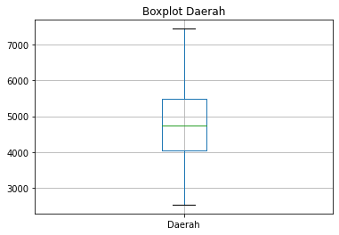

```python
show_boxplot("Daerah", Gandum)
```

### **Nilai Rata-rata Sumbu Utama tidak sama dengan 116?**

**Menghitung Jumlah Sampel SumbuUtama**

```python
# Mendapatkan nilai atau banyaknya sampel dari data.
n_sample = (Gandum['SumbuUtama'].shape)[0]
print(n_sample)
```

```
500
```

```python
# Cek apakah ada data yang kosong di dalam dataset
Gandum['SumbuUtama'].isnull().any()
```

```
False
```

*Karena tidak ada data yang null atau kosong, maka dapat disimpulkan bahwa untuk kolom `SumbuUtama` pada dataset Gandum, terdapat sebanyak 500 sampel data dan untuk pengujian hipotesis diasumsikan bahwa sampel data ini bersifat acak.*

**Melakukan Tes Hipotesis dengan Metode Tes Statistik Z**

1. Menentukan bahwa Null Hypothesis dari pengujian ini adalah nilai rata-rata dari SumbuUtama adalah 116, yaitu H$_{0}$: `μ = 116`.
2. Hipotesis Alternatif yang ditentukan adalah bahwa nilai rata-rata dari SumbuUtama bukan 116, yaitu H$_{1}$: μ $\neq$ 116.
3. Menentukan Tingkat Signifikansi yang digunakan, yaitu `α = 0.05`.
4. Menentukan metode yang digunakan, yaitu `Tes Statistik Z`, karena sampel SumbuUtama memiliki ukuran yang cukup besar (`n > 30`), sehingga meskipun SumbuUtama tidak berdistribusi normal, metode tes statistik ini masih bisa dan cocok digunakan untuk menguji hipotesis tersebut. Selain itu, untuk hipotesis tak berarah H$_{1}$ seperti pada nomor 2, maka digunakan `Two-Tailed Test`. Dengan `α = 0.05`, maka didapatkan bahwa daerah kritis dari pengecekan ini untuk z$_{α_/2}$ adalah `z > 1.96` atau `z < -1.96`.

*Penarikan kesimpulan dilakukan utamanya dengan menggunakan konsep daerah kritis ini. Jika hipotesis nol ditolak, otomatis nilai p kurang dari taraf signifikansi yang digunakan, dan berlaku sebaliknya. Penarikan kesimpulan dengan p-value juga sama: jika p-value kurang dari taraf signifikansi yang ditetapkan, maka hipotesis nol ditolak, jika tidak maka kita gagal menolak hipotesis nol tersebut.*

```python
def two_tailed_test(z_score):
  # Two-Tailed Test dengan α = 0.05, sehingga daerah kritis ada di range z < -1.96 atau z > 1.96.
  if(z_score > 1.96 or z_score < -1.96):
    print("Hipotesis nol ditolak karena nilai z masuk ke dalam critical region.")
  else:
    print("Hipotesis nol gagal ditolak karena nilai z tidak masuk ke dalam critical region.")
  print("Nilai z-score yang dihasilkan adalah", z_score)
  print("P-Value yang dihasilkan untuk z-score tersebut adalah", 2 * scipy.stats.norm.sf(abs(z_score)))
```

Mendapatkan nilai $\bar{x}$, μ$_{0}$, dan σ untuk SumbuUtama

```python
x_bar = Gandum["SumbuUtama"].mean()
miu = 116
std = Gandum["SumbuUtama"].std()
```

```python
# 5. Menentukan Nilai z-score
z_score = count_z_score(x_bar, miu, std, n_sample)

# 6. Menentukan apabila hipotesis nol ditolak atau tidak bisa ditolak
two_tailed_test(z_score)
```

```
Hipotesis nol gagal ditolak karena nilai z tidak masuk ke dalam critical region.
Nilai z-score yang dihasilkan adalah 0.055247123267335795
P-Value yang dihasilkan untuk z-score tersebut adalah 0.9559415872977244
```

*Dari pengujian hipotesis, didapatkan bahwa nilai z-score tidak masuk ke dalam daerah kritis sehingga $H_0$ gagal ditolak untuk taraf signifikansi `α = 0.05`. Implikasi yang sama juga diberikan untuk nilai `p-value` di atas. Meskipun kita belum bisa menyatakan bahwa hipotesis nol tersebut sepenuhnya benar, namun secara kasar kita bisa mengatakan bahwa hipotesis nol tersebut benar sehingga Sumbu Utama memiliki rata-rata 116.*

**Boxplot Sumbu Utama**

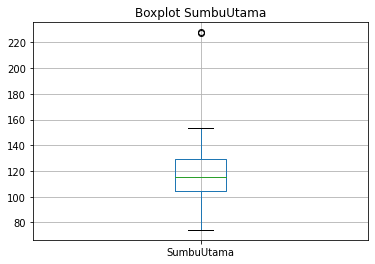

```python
show_boxplot("SumbuUtama", Gandum)
```

### **Nilai Rata-rata 20 baris pertama kolom Sumbu Kecil bukan 50?**

**Mendapatkan 20 baris pertama kolom SumbuKecil**

```python
# 20 Baris Pertama Kolom Sumbu Kecil
sk_first_20 = Gandum["SumbuKecil"].iloc[:20]
n_sample = (sk_first_20.shape)[0]
print(n_sample)
```

```
20
```

```python
# Cek apabila ada data kosong atau null
sk_first_20.isnull().any()
```

```
False
```

*Karena tidak ada data yang null atau kosong, maka dapat disimpulkan bahwa untuk kolom `SumbuKecil` pada dataset Gandum, terdapat sebanyak 20 sampel data dan untuk pengujian hipotesis diasumsikan bahwa sampel data ini bersifat acak.*

**Melakukan Tes Hipotesis dengan Metode Tes Statistik T**

1. Menentukan bahwa Null Hypothesis dari pengujian ini adalah nilai rata-rata dari 20 baris pertama SumbuKecil adalah 50, yaitu H$_{0}$: `μ = 50`.
2. Hipotesis Alternatif yang ditentukan adalah bahwa nilai rata-rata dari 20 baris pertama SumbuKecil bukan 50, yaitu H$_{1}$: μ $\neq$ 50.
3. Menentukan Tingkat Signifikansi yang digunakan, yaitu `α = 0.05`.
4. Menentukan metode yang digunakan, yaitu `Tes Statistik T`, karena sampel SumbuKecil memiliki ukuran yang sangat kecil (`n < 30`), sehingga metode tes statistik ini lebih cocok digunakan untuk menguji hipotesis tersebut dibandingkan metode tes statistik z. Selain itu, untuk hipotesis tak berarah H$_{1}$ seperti pada nomor 2, maka digunakan `Two-Tailed Test`.

*Penarikan kesimpulan dilakukan utamanya dengan menggunakan konsep daerah kritis ini. Jika hipotesis nol ditolak, otomatis nilai p kurang dari taraf signifikansi yang digunakan, dan berlaku sebaliknya. Penarikan kesimpulan dengan p-value juga sama: jika p-value kurang dari taraf signifikansi yang ditetapkan, maka hipotesis nol ditolak, jika tidak maka kita gagal menolak hipotesis nol tersebut.*

**Menentukan Daerah Kritis**

Dari bagian pertama dapat diketahui bahwa jumlah sampel yang ada untuk pengujian ini adalah `n = 20`. Dengan menggunakan jumlah sampel ini, maka akan didapatkan derajat kebebasan untuk pengujian ini, yaitu `df = n - 1 = 19`. Dengan `α = 0.05` dan `df = 19`, maka didapatkan bahwa daerah kritis dari pengecekan ini untuk t$_{α_/2}$ adalah `t > 2.09302` atau `t < -2.09302`.

```python
def two_tailed_t_test(t_score, n_sample):
  # Two-Tailed T-Test dengan α = 0.05, sehingga daerah kritis ada di range t < -2.09302 atau t > 2.09302.
  if(t_score > 2.09302 or t_score < -2.09302):
    print("Hipotesis nol ditolak karena nilai t masuk ke dalam critical region.")
  else:
    print("Hipotesis nol gagal ditolak karena nilai t tidak masuk ke dalam critical region.")
  print("Nilai t-score yang dihasilkan adalah", t_score)
  print("P-Value yang dihasilkan untuk t-score tersebut adalah", 2 * scipy.stats.t.sf(abs(t_score), n_sample - 1))
```

Mendapatkan nilai $\bar{x}$, μ$_{0}$, dan σ untuk SumbuKecil

```python
x_bar = sk_first_20.mean()
miu = 50
std = sk_first_20.std()
```

```python
# 5. Menentukan Nilai t-score
t_score = count_t_score(x_bar, miu, std, n_sample)

# 6. Menentukan apabila hipotesis nol ditolak atau tidak bisa ditolak
two_tailed_t_test(t_score, n_sample)
```

```
Hipotesis nol ditolak karena nilai t masuk ke dalam critical region.
Nilai t-score yang dihasilkan adalah 6.478168916968886
P-Value yang dihasilkan untuk t-score tersebut adalah 3.30201856442456e-06
```

*Dari pengujian hipotesis, didapatkan bahwa nilai t-score masuk ke dalam daerah kritis sehingga $H_0$ ditolak untuk taraf signifikansi `α = 0.05`. Implikasi yang sama juga diberikan untuk nilai `p-value` di atas. Hal ini berarti bahwa hipotesis alternatif lebih mungkin terjadi pada data `Sumbu Kecil`, atau dalam kata lain data `Sumbu Kecil` memiliki rata-rata yang tidak sama dengan 50. Karena tes yang dilakukan berupa `two-tailed test` dan hasil perhitungan t-score jatuh ke `right-tail side` dari daerah kritis, maka dapat diduga dengan kuat bahwa rata-rata dari `Sumbu Kecil` lebih besar dari `50`.*

**Boxplot SumbuKecil**

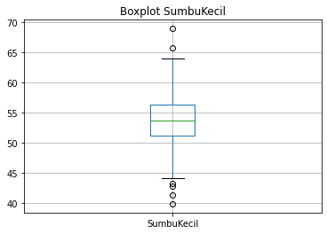

```python
show_boxplot("SumbuKecil", Gandum)
```

### **Proporsi nilai Diameter yang lebih dari 85, adalah tidak sama dengan 15% ?**

**Mendapatkan data Diameter yang bernilai lebih dari 85**

```python
# Data Diameter dengan nilai lebih dari 85
bigger_d_than_85 = Gandum["Diameter"].loc[Gandum["Diameter"] > 85]
bigger_than_85 = (bigger_d_than_85.shape)[0]
n_sample = (Gandum["Diameter"].shape)[0]

print(bigger_than_85)
print(n_sample)
```

```
97
500
```

*Karena sudah pasti tidak ada data yang null atau kosong, maka dapat disimpulkan bahwa untuk kolom `Diameter` pada dataset Gandum, terdapat sebanyak 97 data dari 500 data dengan nilai lebih dari 85 dan untuk pengujian hipotesis diasumsikan bahwa sampel data ini bersifat acak.*

**Melakukan Tes Hipotesis dengan Metode Tes Statistik Z**

1. Menentukan bahwa Null Hypothesis dari pengujian ini adalah proporsi nilai Diameter yang lebih dari 85 sama dengan 15%, yaitu H$_{0}$: `p = 0.15`.
2. Hipotesis Alternatif yang ditentukan adalah bahwa proporsi data Diameter yang nilainya lebih dari 85 tidak sama dengan 15%, yaitu H$_{1}$: p $\neq$ 0.15.
3. Menentukan Tingkat Signifikansi yang digunakan, yaitu `α = 0.05`.
4. Menentukan metode yang digunakan, yaitu `Tes Statistik Z`, karena data Diameter memiliki ukuran yang cukup besar `(n > 30)` dan sudah berdistribusi normal berdasarkan pengujian sebelumnya sehingga data ini sangat cocok diuji dengan Z-Test. Selain itu, untuk hipotesis tak berarah $H_{1}$ seperti pada nomor 2, maka digunakan `Two-Tailed Test`. Dengan `α = 0.05`, maka didapatkan bahwa daerah kritis dari pengecekan ini untuk z$_{α/2}$ adalah `z > 1.96` atau `z < -1.96`.

*Penarikan kesimpulan dilakukan utamanya dengan menggunakan konsep daerah kritis ini. Jika hipotesis nol ditolak, otomatis nilai p kurang dari taraf signifikansi yang digunakan, dan berlaku sebaliknya. Penarikan kesimpulan dengan p-value juga sama: jika p-value kurang dari taraf signifikansi yang ditetapkan, maka hipotesis nol ditolak, jika tidak maka kita gagal menolak hipotesis nol tersebut.*

**Menentukan Nilai Z dari Proporsi**

*Pengujian dengan `Two-Tailed Test` bisa dilakukan dengan menggunakan prosedur yang telah dibuat pada bagian sebelumnya. Namun, perhitungan z-score untuk persoalan proporsi berbeda dengan persoalan mean sehingga kalkulasi nilai z akan menggunakan fungsi baru berikut.*

```python
def count_z_proportion(n_sample, x_from_n_sample, p_naught):
  p_hat = x_from_n_sample / n_sample
  q_naught = 1 - p_naught
  return((p_hat - p_naught) / math.sqrt((p_naught * q_naught) / n_sample))
```

```python
x_from_n_sample = bigger_than_85
p_naught = 0.15
```

```python
# 5. Menentukan Nilai z-score
z_score = count_z_proportion(n_sample, x_from_n_sample, p_naught)

# 6. Menentukan apabila hipotesis nol ditolak atau tidak bisa ditolak
two_tailed_test(z_score)
```

```
Hipotesis nol ditolak karena nilai z masuk ke dalam critical region.
Nilai z-score yang dihasilkan adalah 2.755386880774658
P-Value yang dihasilkan untuk z-score tersebut adalah 0.005862277168409654
```

*Dari pengujian hipotesis, didapatkan bahwa nilai z-score masuk ke dalam daerah kritis sehingga $H_0$ ditolak untuk taraf signifikansi `α = 0.05`. Implikasi yang sama juga diberikan untuk nilai `p-value` di atas. Hal ini berarti bahwa hipotesis alternatif lebih mungkin terjadi pada data `Diameter`, atau dalam kata lain data `Diameter` yang bernilai lebih dari 85 memiliki proporsi yang tidak sama dengan 15%. Karena tes yang dilakukan berupa `two-tailed test` dan hasil perhitungan z-score jatuh ke `right-tail side` dari daerah kritis, maka dapat diduga dengan kuat bahwa proporsi data `Diameter` yang bernilai lebih dari 85 lebih besar dari `15%`.*

**Boxplot Diameter**

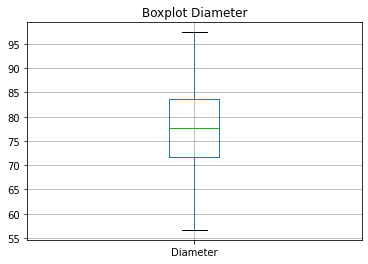

```python
show_boxplot("Diameter", Gandum)
```

### **Proporsi nilai Keliling yang kurang dari 100, adalah kurang dari 5% ?**

**Mendapatkan data Keliling yang bernilai kurang dari 100**

```python
# Data Keliling dengan nilai kurang dari 100
less_k_than_100 = Gandum["Keliling"].loc[Gandum["Keliling"] < 100]
less_than_100 = (less_k_than_100.shape)[0]
n_sample = (Gandum["Keliling"].shape)[0]

print(less_than_100)
print(n_sample)
```

```
0
500
```

*Karena sudah pasti tidak ada data yang null atau kosong, maka dapat disimpulkan bahwa untuk kolom `Keliling` pada dataset Gandum, terdapat sebanyak 500 data dari 500 data dengan nilai lebih dari 100 dan untuk pengujian hipotesis diasumsikan bahwa sampel data ini bersifat acak.*

**Melakukan Tes Hipotesis dengan Metode Tes Statistik Z**

1. Menentukan bahwa Null Hypothesis dari pengujian ini adalah proporsi nilai Keliling yang kurang dari 100 sama dengan 5%, yaitu H$_{0}$: `p = 0.05`.
2. Hipotesis Alternatif yang ditentukan adalah bahwa proporsi data Keliling yang bernilai kurang dari 100 adalah kurang dari 5%, yaitu H$_{1}$: `p < 0.05`.
3. Menentukan Tingkat Signifikansi yang digunakan, yaitu `α = 0.05`.
4. Menentukan metode yang digunakan, yaitu `Tes Statistik Z`, karena data Keliling memiliki ukuran yang cukup besar `(n > 30)`, sehingga meskipun Keliling tidak berdistribusi normal, metode tes statistik ini masih bisa dan cocok digunakan untuk menguji hipotesis tersebut. Selain itu, untuk hipotesis berarah $H_{1}$ seperti pada nomor 2, maka digunakan `One-Tailed Test`. Dengan `α = 0.05`, maka didapatkan bahwa daerah kritis dari pengecekan ini untuk z$_{α}$ adalah `z < -1.645`.

*Penarikan kesimpulan dilakukan utamanya dengan menggunakan konsep daerah kritis ini. Jika hipotesis nol ditolak, otomatis nilai p kurang dari taraf signifikansi yang digunakan, dan berlaku sebaliknya. Penarikan kesimpulan dengan p-value juga sama: jika p-value kurang dari taraf signifikansi yang ditetapkan, maka hipotesis nol ditolak, jika tidak maka kita gagal menolak hipotesis nol tersebut.*

**Menentukan Nilai Z dari Proporsi**

*Pengujian dengan `One-Tailed Test` tidak bisa dilakukan dengan menggunakan prosedur yang telah dibuat pada bagian sebelumnya, karena kedua pengujian ini memiliki daerah kritis yang berbeda. Daerah kritis yang berbeda ini dipengaruhi oleh arah yang dimiliki oleh Hipotesis Alternatif yang telah didefinisikan sebelumnya. Perhitungan z-score untuk persoalan proporsi ini bisa dilakukan dengan menggunakan fungsi yang telah didefinisikan untuk persoalan proporsi sebelumnya.*

```python
def one_tailed_test2(z_score):
  # One-Tailed Test dengan α = 0.05, sehingga daerah kritis ada di range z < -1.645 berdasarkan tabel z.
  if(z_score < -1.645):
    print("Hipotesis nol ditolak karena nilai z masuk ke dalam critical region.")
  else:
    print("Hipotesis nol gagal ditolak karena nilai z tidak masuk ke dalam critical region.")
  print("Nilai z-score yang dihasilkan adalah", z_score)
  print("P-Value yang dihasilkan untuk z-score tersebut adalah", scipy.stats.norm.sf(abs(z_score)))
```

```python
x_from_n_sample = less_than_100
p_naught = 0.05
```

```python
# 5. Menentukan Nilai z-score
z_score = count_z_proportion(n_sample, x_from_n_sample, p_naught)

# 6. Menentukan apabila hipotesis nol ditolak atau tidak bisa ditolak
one_tailed_test2(z_score)
```

```
Hipotesis nol ditolak karena nilai z masuk ke dalam critical region.
Nilai z-score yang dihasilkan adalah -5.129891760425771
P-Value yang dihasilkan untuk z-score tersebut adalah 1.4495441414387716e-07
```

*Dari pengujian hipotesis, didapatkan bahwa nilai z-score masuk ke dalam daerah kritis sehingga $H_0$ ditolak untuk taraf signifikansi `α = 0.05`. Implikasi yang sama juga diberikan untuk nilai `p-value` di atas. Hal ini berarti bahwa hipotesis alternatif lebih mungkin terjadi pada data `Keliling`, atau dalam kata lain data `Keliling` yang bernilai kurang dari 100 memiliki proporsi yang kurang dari `5%`.*

**Boxplot Keliling**

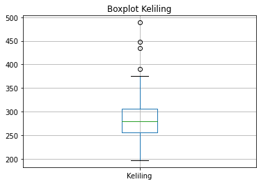

```python
show_boxplot("Keliling", Gandum)
```

# Nomor 5: Tes Hipotesis 2 Sampel

```python
def z_test(data1, data2, d0 = 0):
  x1_bar = data1.mean()
  x2_bar = data2.mean()
  std1 = data1.std()
  std2 = data2.std()
  n1 = data1.shape[0]
  n2 = data2.shape[0]

  return ((x1_bar - x2_bar) - d0)/((((std1**2)/n1) + ((std2**2)/n2)) ** 0.5)
```

*Jika suatu hipotesis nol ditolak melalui pengujian hipotesis, maka dapat dikatakan bahwa hipotesis alternatif merupakan pernyataan yang benar. Hal ini dikarenakan nilai dari p-value yang dihasilkan secara tidak langsung menyatakan bahwa lebih condong dan memungkinkan bagi hipotesis alternatif untuk terjadi dibandingkan dengan hipotesis nol yang dinyatakan sebelumnya.*

### **Data kolom AreaBulatan dibagi 2 sama rata: bagian awal dan bagian akhir kolom.Benarkah rata-rata kedua bagian tersebut sama?**

1. Null Hypotesis H$_{0}$ : μ$_{1}$ - μ$_{2}$ = 0
2. Hipotesis alternatif H$_{1}$ : μ$_{1}$ - μ$_{2}$ $\neq$ 0
3. Tingkat signifikan alfa = 0.05
4. **Uji statistik yang sesuai => Z test** karena data lebih dari 30 dan standar deviasi masing-masing dapat diketahui. Daerah kritisnya adalah Z < -Z$_{0.025}$ atau Z > Z$_{0.025}$ (Z < -1.96 atau Z > 1.96) karena merupakan `two-tailed test` yang disebabkan oleh hipotesis alternatif yang tidak berarah.

```python
data1 = Gandum.iloc[:int(n_sample/2)]["AreaBulatan"]
data2 = Gandum.iloc[(int(n_sample/2)):]["AreaBulatan"]
z = z_test(data1, data2)
two_tailed_test(z)
```

```
Hipotesis nol ditolak karena nilai z masuk ke dalam critical region.
Nilai z-score yang dihasilkan adalah 17.013036648485464
P-Value yang dihasilkan untuk z-score tersebut adalah 6.574024595618948e-65
```

```python
data1.name = "Awal"
data2.name = "Akhir"
area_bulatan = pd.concat([data1, data2.reset_index()], axis = 1)
area_bulatan.drop(columns= ['index'], axis = 1, inplace = True)
```

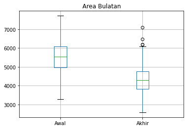

```python
area_bulatan.boxplot(column = ["Awal", "Akhir"])
plt.title("Area Bulatan")
plt.show()
```

### **Data kolom Kadar Air dibagi 2 sama rata: bagian awal dan bagian akhir kolom. Benarkah rata-rata bagian awal lebih besar dari pada bagian akhir sebesar 0.2?**

1. Null Hypotesis H$_{0}$ : μ$_{1}$ - μ$_{2}$ = 0.2
2. Hipotesis alternatif H$_{1}$ : μ$_{1}$ - μ$_{2}$ > 0.2
3. Tingkat signifikan alfa = 0.05
4. Uji statistik yang sesuai => Z test karena data lebih dari 30 dan standar deviasi masing-masing dapat diketahui. Daerah kritisnya adalah Z > Z$_{0.05}$ (Z > 1.645) karena merupakan `one-tailed test` yang disebabkan oleh hipotesis alternatif berarah.

```python
data1 = Gandum.iloc[:int(n_sample/2), :]["KadarAir"]
data2 = Gandum.iloc[(int(n_sample/2)):, :]["KadarAir"]
z = z_test(data1, data2, 0.2)
one_tailed_test(z)
```

```
Hipotesis nol gagal ditolak karena nilai z tidak masuk ke dalam critical region.
Nilai z-score yang dihasilkan adalah -26.903444249744958
P-Value yang dihasilkan untuk z-score tersebut adalah 1.0008041428008981e-159
```

```python
data1.name = "Awal"
data2.name = "Akhir"
kadar_air = pd.concat([data1, data2.reset_index()], axis = 1)
kadar_air.drop(columns= ['index'], axis = 1, inplace = True)
```

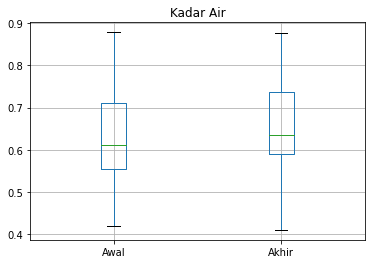

```python
kadar_air.boxplot(column = ["Awal", "Akhir"])
plt.title("Kadar Air")
plt.show()
```

### **Rata-rata 20 baris pertama kolom Bulatan sama dengan 20 baris terakhirnya?**

```python
data1 = Gandum.iloc[:20]["Bulatan"]
data2 = Gandum.iloc[-20:]["Bulatan"]
z = z_test(data1, data2)
two_tailed_test(z)
```

```
Hipotesis nol ditolak karena nilai z masuk ke dalam critical region.
Nilai z-score yang dihasilkan adalah -3.3792268633124025
P-Value yang dihasilkan untuk z-score tersebut adalah 0.0007268999745854886
```

1. Nilai z = -3.3792268633124025, p-value = 0.0007268999745854886
2. Karena nilai z ada di dalam daerah kritis dan p-value < 0.05 maka hipotesis null ditolak dan hipotesis alternatif diterima sehingga dapat dikatakan bahwa pernyataan mengenai rata-rata 20 baris pertama dengan 20 baris terakhir tidak sama adalah benar.

```python
data1.name = "20_baris_awal"
data2.name = "20_baris_akhir"
bulatan = pd.concat([data1, data2.reset_index()], axis = 1)
bulatan.drop(columns= ['index'], axis = 1, inplace = True)
```

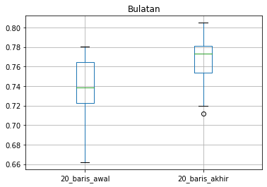

```python
bulatan.boxplot(column = ["20_baris_awal", "20_baris_akhir"])
plt.title("Bulatan")
plt.show()
```

### **Proporsi nilai bagian awal Ransum yang lebih dari 2, adalah lebih besar daripada, proporsi nilai yang sama di bagian akhir Ransum?**

1. Null Hypotesis H$_{0}$ : p$_{1}$ - p$_{2}$ = 0
2. Hipotesis alternatif H$_{1}$ : p$_{1}$ - p$_{2}$ $\gt$ 0
3. Tingkat signifikan alfa = 0.05
4. Uji statistik yang sesuai => Z test karena data lebih dari 30 dan standar deviasi masing-masing dapat diketahui. Daerah kritisnya adalah Z > Z$_{0.05}$ (Z > 1.645)

```python
data1 = (Gandum["Ransum"][:int(n_sample/2)]).loc[lambda x: x > 2]
data2 = (Gandum["Ransum"][int(n_sample/2):]).loc[lambda x: x > 2]
p1 = len(data1) / int(n_sample / 2)
p2 = len(data2) / int(n_sample / 2)
pTotal = (len(data1) + len(data2)) / 500

zValue = (p1 - p2) / ((pTotal * (1 - pTotal) * (1 / len(data1) + 1 / len(data2))))**0.5

one_tailed_test(zValue)
```

```
Hipotesis nol ditolak karena nilai z masuk ke dalam critical region.
Nilai z-score yang dihasilkan adalah 10.659836807605831
P-Value yang dihasilkan untuk z-score tersebut adalah 7.843623083814553e-27
```

1. Nilai z = 10.659836807605831, Nilai p = 7.843623083814553e-27
2. Karena nilai z berada di daerah kritis dan p-value < 0.05 maka hipotesis nol ditolak dan hipotesis alternatif diterima sehingga secara kasar dapat dikatakan bahwa proporsi nilai bagian awal Ransum yang lebih dari 2 lebih besar daripada proporsi nilai yang sama di bagian akhir ransum.

```python
data1.name = "Awal"
data2.name = "Akhir"
ransum = pd.concat([data1, data2.reset_index()], axis = 1)
ransum.drop(columns= ['index'], axis = 1, inplace = True)
```

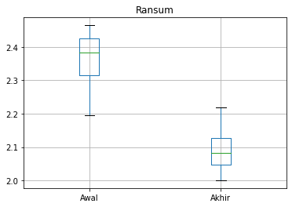

```python
np.warnings.filterwarnings('ignore', category=np.VisibleDeprecationWarning)
ransum.boxplot(column = ["Awal", "Akhir"])
plt.title("Ransum")
plt.show()
```

### **Bagian awal kolom Diameter memiliki variansi yang sama dengan bagian akhirnya**

```python
data1 = Gandum["Diameter"][:int(n_sample/2)]
data2 = Gandum["Diameter"][int(n_sample/2):]
varians_data1 = (data1.std())**2
varians_data2 = (data2.std())**2
f = varians_data1 / varians_data2
print("F-Score yang dihasilkan adalah", f)
print("P-Value yang dihasilkan untuk f-score tersebut adalah", scipy.stats.f.sf(f, 249, 249))
```

```
F-Score yang dihasilkan adalah 1.083878022042188
P-Value yang dihasilkan untuk f-score tersebut adalah 0.26278959201894364
```

```python
data1.name = "Awal"
data2.name = "Akhir"
diameter = pd.concat([data1, data2.reset_index()], axis = 1)
diameter.drop(columns= ['index'], axis = 1, inplace = True)
```

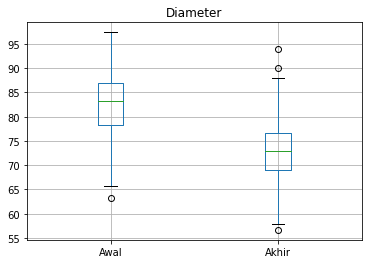

```python
diameter.boxplot(column = ["Awal", "Akhir"])
plt.title("Diameter")
plt.show()
```

# Nomor 6: *Correlation Test*

### **Tes Hipotesis untuk Mengecek Korelasi**

```python
Gandum.shape
```

```
(500, 12)
```

```python
Gandum.isnull().any()
```

```
id             False
Daerah         False
SumbuUtama     False
SumbuKecil     False
Keunikan       False
AreaBulatan    False
Diameter       False
KadarAir       False
Keliling       False
Bulatan        False
Ransum         False
Kelas          False
dtype: bool
```

Untuk semua data yang ada di dalam dataset `Gandum`, dapat diketahui bahwa semua kolom berisikan masing-masing 500 buah data. Untuk setiap kolom yang ada akan berlaku pengujian hipotesis berikut untuk mengecek apabila ada atau tidaknya korelasi antara kolom non-target dengan kolom target `(Kelas)`.

1. Menentukan bahwa Null Hypothesis dari pengujian ini adalah data pertama yang selanjutnya merupakan fitur-fitur non-target, dan data kedua yang merupakan fitur target, tidak memiliki korelasi linear, yaitu H$_{0}$: `ρ = 0`.
2. Hipotesis Alternatif yang ditentukan adalah bahwa data pertama yang selanjutnya merupakan fitur-fitur non-target, dan data kedua yang merupakan fitur target, memiliki korelasi linear, yaitu H$_{1}$: $ρ \neq 0$.
3. Menentukan Tingkat Signifikansi yang digunakan, yaitu `α = 0.05`.
4. Menentukan metode yang digunakan, yaitu `Tes Statistik T`, untuk menguji sebuah korelasi antara dua buah variabel yang dalam hal ini diuji secara umum, ada atau tidak. Untuk hipotesis tidak berarah H$_{1}$ seperti yang telah didefinisikan pada nomor 2, maka digunakan `Two-Tailed Test`.

Dari bagian pertama dapat diketahui bahwa jumlah sampel yang ada untuk pengujian ini adalah `n = 500`. Dengan menggunakan jumlah populasi sebagai sampel ini, maka akan didapatkan derajat kebebasan untuk pengujian korelasi yang berbeda dengan derajat kebebasan pada pengujian hipotesis satu sampel, yaitu `df = n - 2 = 498`. Hal ini dikarenakan korelasi berkaitan erat dengan dua titik yang bisa membentuk garis dan menggambarkan sebuah korelasi, sehingga derajat kebebasan didapat dengan mengurangi jumlah sampel dengan 2. Dengan `α = 0.05` dan `df = 498`, maka didapatkan bahwa daerah kritis dari pengecekan ini untuk t$_{α_/2}$ adalah `t > 1.964739` atau `t < -1.964739`.

*Penarikan kesimpulan dilakukan utamanya dengan menggunakan konsep daerah kritis ini. Jika hipotesis nol ditolak, otomatis nilai p kurang dari taraf signifikansi yang digunakan, dan berlaku sebaliknya. Penarikan kesimpulan dengan p-value juga sama: jika p-value kurang dari taraf signifikansi yang ditetapkan, maka hipotesis nol ditolak, jika tidak maka kita gagal menolak hipotesis nol tersebut.*

**Menghitung Nilai Koefisien r**

```python
# Calculate r-score
def r_score(data1, data2):
  # Convert to list for easier computation
  # Data 1 -> Features, Data 2 -> Target
  data1_list = list(data1)
  data2_list = list(data2)
  n_of_both = len(data1_list) # n of data1 = n of data2

  # Mean of data 1 and data 2
  mean_of_d1 = sum(data1_list) / n_of_both
  mean_of_d2 = sum(data2_list) / n_of_both

  # Numerator of the Equation.
  # Refer to Walpole 432: Correlation Coefficient
  num = 0
  for idx in range(n_of_both):
    num += (data1_list[idx] - mean_of_d1) * (data2_list[idx] - mean_of_d2)

  # Denominator of the Equation: Sum of Squares
  # Refer to Walpole 432: Correlation Coefficient
  Sxx = 0
  Syy = 0
  for data in data1_list:
    Sxx += (data - mean_of_d1)**2
  for data in data2_list:
    Syy += (data - mean_of_d2)**2

  # Get the r-score
  # Refer to Walpole 432: Correlation Coefficient
  return num / math.sqrt(Sxx * Syy)
```

**Menghitung Nilai t Berdasarkan Koefisien r**

```python
def calc_t_score(r_score, n_sample):
  return (r_score * math.sqrt(n_sample - 2)) / math.sqrt(1 - r_score ** 2)
```

**Melakukan *Correlation Test***

```python
def pearson_correlation_test(data1, data2):
  r_value = r_score(data1, data2)
  n_sample = len(list(data1))

  # 5. Menentukan Nilai t-score
  t_score = calc_t_score(r_value, n_sample)

  # Two-Tailed T-Test dengan α = 0.05 dan df = 498, sehingga daerah kritis ada di range t > 1.964739 atau t < -1.964739.
  # 6. Menentukan apabila hipotesis nol ditolak atau tidak bisa ditolak
  if(t_score > 1.964739 or t_score < -1.964739):
    print("Hipotesis nol ditolak karena nilai t masuk ke dalam critical region.")
  else:
    print("Hipotesis nol gagal ditolak karena nilai t tidak masuk ke dalam critical region.")
  print("Nilai t-score yang dihasilkan adalah", t_score)
  print("P-Value yang dihasilkan untuk t-score tersebut adalah", 2 * scipy.stats.t.sf(abs(t_score), n_sample - 2))
```

### **Menampilkan *Scatter Plot* untuk Suatu Data**

```python
def draw_scatter_plot(feature, target, data):
  sns.set(rc={'figure.figsize':(5, 5)})
  scatter = sns.scatterplot(x = target, y = feature, hue = target, data = data)
  plt.tick_params(
    axis='x',          # changes apply to the x-axis
    which='both',      # both major and minor ticks are affected
    bottom=False,      # ticks along the bottom edge are off
    top=False,         # ticks along the top edge are off
    labelbottom=False)
  plt.title("Scatter Plot %s - %s" %(feature.name, target.name))
  plt.show()
```